# Crop Yield

# Import libraries

```r
library(cobalt)
library(WeightIt)
library(lmtest)
library(sandwich)
```

# Task 1

```r
# Load file as dataframe
farm_df = read.csv("farms.csv")
```

# Task 2

```r
# Inspect dataframe
print(head(farm_df))
```

|  | total_yield | cover_10 | region | total_avg | age_avg | experience_avg | insurance_avg | easement_p | conservation_till_avg | fertilizer_per_area |
| --- | --- | --- | --- | --- | --- | --- | --- | --- | --- | --- |
| 1 | 61.33234 | 0 | South | 0.305 | 57.2 | 21.6 | 0.2543968 | 1.8867925 | 145 | 20.26741 |
| 2 | 47.47099 | 1 | South | 0.208 | 61.2 | 24.9 | 0.6386207 | 1.5439430 | 553 | 74.62687 |
| 3 | 46.27485 | 0 | South | 0.307 | 61.0 | 24.5 | 0.4223478 | 0.8032129 | 63 | 15.08367 |
| 4 | 81.77405 | 0 | South | 0.254 | 58.8 | 23.9 | 1.0557846 | 1.1844332 | 391 | 60.03353 |
| 5 | 81.04827 | 0 | South | 0.117 | 58.0 | 23.9 | 0.2556000 | 0.5053341 | 27 | 22.93760 |
| 6 | 58.26087 | 0 | South | 0.292 | 62.5 | 23.6 | 0.6138043 | 2.3454158 | 579 | 25.26148 |

# Task 3

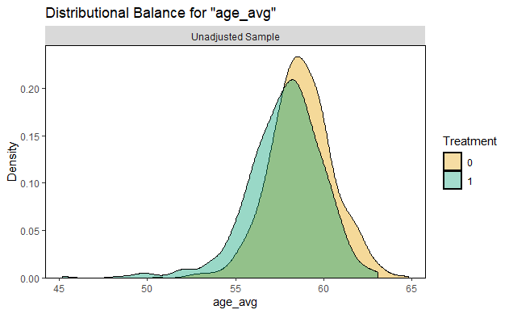

```r
# Balance plot for the average age
bal.plot(
  x = cover_10 ~ age_avg, #formula
  data = farm_df, #dataset
  var.name = "age_avg", #variable
  colors = c("#E69F00", "#009E73") #set fill colors
)
```

# Task 4

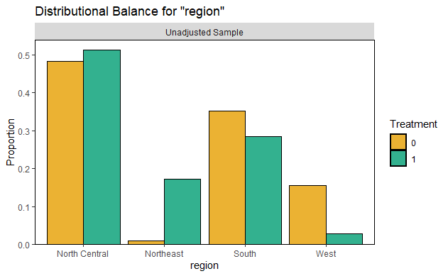

```r
# Balance plot for geographic region
bal.plot(
  x = cover_10 ~ region, #formula
  data = farm_df, #dataset
  var.name = "region", #variable
  colors = c("#E69F00", "#009E73") #set fill colors
)
```

# Task 5

```r
# Balance table to show SMD and variance ratio of between groups
bal.tab(
  x = cover_10 ~ region + total_avg + age_avg + experience_avg + insurance_avg + easement_p+ conservation_till_avg + fertilizer_per_area, #formula
  data = farm_df, #dataset
  disp.v.ratio = TRUE, #display variance ratio
  binary = "std" #SMDs for binary variables
)
```

```
Note: 's.d.denom' not specified; assuming pooled.
```

```
Balance Measures
                         Type Diff.Un V.Ratio.Un
region_North Central   Binary  0.0627          .
region_Northeast       Binary  0.5896          .
region_South           Binary -0.1454          .
region_West            Binary -0.4488          .
total_avg             Contin. -0.4775     0.2499
age_avg               Contin. -0.4668     1.4521
experience_avg        Contin.  0.1226     0.7960
insurance_avg         Contin. -0.4963     0.4423
easement_p            Contin.  0.2982     1.1288
conservation_till_avg Contin. -0.3670     0.6057
fertilizer_per_area   Contin.  0.6299     1.5627

Sample sizes
    Control Treated
All    1048     529
```

# Task 6

```r
# Calculate IPTW weights with initial propensity score model
farm_iptw = weightit(
  formula = cover_10 ~ region + total_avg + insurance_avg + fertilizer_per_area,
  data = farm_df,
  method =  "ps",
  estimand = "ATE"
)
print(farm_iptw)
```

```
A weightit object
 - method: "ps" (propensity score weighting)
 - number of obs.: 1577
 - sampling weights: none
 - treatment: 2-category
 - estimand: ATE
 - covariates: region, total_avg, insurance_avg, fertilizer_per_area
```

# Task 7

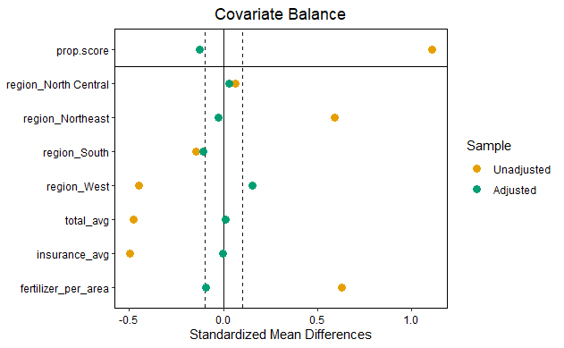

```r
# Love plot with threshold lines to show SMD balance before and after weighting
love.plot(
  x = farm_iptw, #weightit object
  binary = "std", #use SMD
  thresholds = c(m = 0.1), #guidelines
  colors = c("#E69F00", "#009E73") #sets fill colors
)
```

# Task 8

```r
# Re-calculate IPTW weights with updated propensity score model
farm_iptw2 = weightit(
  formula = cover_10 ~ region + total_avg + insurance_avg + age_avg + experience_avg + easement_p + conservation_till_avg,
  data = farm_df,
  method =  "ps",
  estimand = "ATE"
)
print(farm_iptw2)
```

```
A weightit object
 - method: "ps" (propensity score weighting)
 - number of obs.: 1577
 - sampling weights: none
 - treatment: 2-category
 - estimand: ATE
 - covariates: region, total_avg, insurance_avg, age_avg, experience_avg, easement_p, conservation_till_avg
```

# Task 9

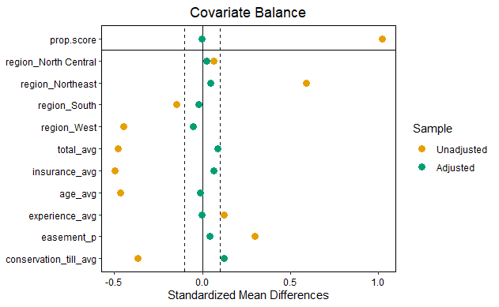

```r
# Plot Love plot of SMDs with threshold lines to show balance before and after IPTW procedure
love.plot(
  x = farm_iptw2, #weightit object
  binary = "std", #use SMD
  thresholds = c(m = 0.1), #guidelines
  colors = c("#E69F00", "#009E73") #sets fill colors
)
```

# Task 10

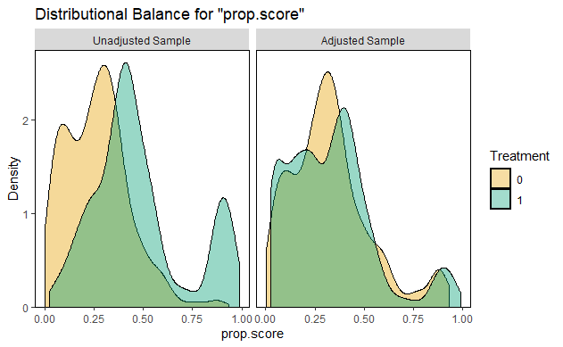

```r
# Balance plot of propensity scores before and after weighting
# Balance plot for propensity scores
bal.plot(
  x = farm_iptw2, #weightit object
  var.name = "prop.score", #propensity scores
  which = "both", #before and after
  colors = c("#E69F00", "#009E73") #sets fill colors
)
```

### Do the distributions of the weighted propensity scores look closer to identical, and are they overlapping each other? Yes the distributions of the weighted propensity scores look closer to identical and they are overlapping each other more.

# Task 11

```r
# Fit outcome regression model
yield_mod <- glm(
  formula = total_yield ~ cover_10 + region + total_avg + insurance_avg + age_avg + experience_avg + easement_p + conservation_till_avg,
  data = farm_df,
  weights = farm_iptw2$weights
)
```

# Task 12

```r
# Estimate regression coefficients for weighted outcome model with robust standard errors
coeftest(
  yield_mod, #weighted outcome model
  vcov. = vcovHC #robust standard errors
)
```

```
z test of coefficients:

                         Estimate  Std. Error z value  Pr(>|z|)
(Intercept)           111.0182307  15.4101202  7.2042 5.837e-13 ***
cover_10                3.5768404   1.0373046  3.4482 0.0005643 ***
regionNortheast        -7.8566450   2.4221267 -3.2437 0.0011799 **
regionSouth            -3.6146891   1.4750675 -2.4505 0.0142648 *
regionWest             18.5398103   2.9171803  6.3554 2.079e-10 ***
total_avg             -18.1552947   2.1255363 -8.5415 < 2.2e-16 ***
insurance_avg           6.2900784   2.2013023  2.8574 0.0042708 **
age_avg                -1.7556714   0.2890145 -6.0747 1.242e-09 ***
experience_avg          2.1238056   0.3191488  6.6546 2.841e-11 ***
easement_p              0.2464213   0.1659482  1.4849 0.1375627
conservation_till_avg  -0.0048407   0.0016546 -2.9256 0.0034379 **
---
Signif. codes:  0 ‘***’ 0.001 ‘**’ 0.01 ‘*’ 0.05 ‘.’ 0.1 ‘ ’ 1
```

# Task 13

## Results Interpretation: if at least 10% of farms in a county employ cover crops (plants used to slow erosion, return nutrients to the soil, and help smother weeds and control pests), the average total yield of wheat increases by 3.6 bushels per acre.

## The Average Treatment Effect (ATE) represents the average effect of the treatment on the entire population, including both those who received the treatment and those who did not. It is an estimate because it is not possible to actually see the effect on the whole population.

## The Average Treatment Effect on the Treated (ATT) represents the effect of the treatment on only those who received the treatment.